# Case Study01: Study of US Craft Beer and Breweries

Adeel & Amita

October 13, 2018

## CASE STUDY 01 - October 18

## Introduction and Overview

In this report, we explore datasets for various `beers` and the `breweries` that produce them in the US. The steps and procedures taken for this analysis are detailed below.

### 1. How many breweries are present in each state?

We answer this question by retrieving the value of `State` from the `Breweries` data.

Generate the plot, group by state

Graph shows the Colorado, Califorina and Michigan has the highest number of Breweries

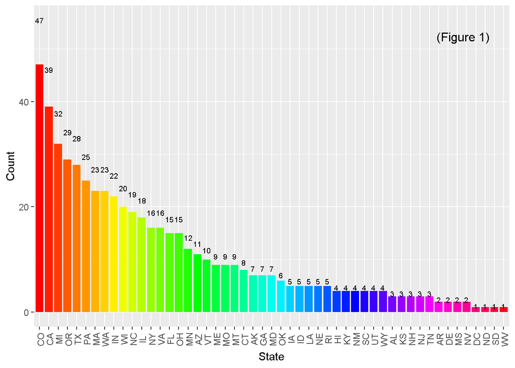

```r
ggplot(data, aes(reorder(State, -Count), Count, label = Count)) +
  geom_bar(stat = "identity", width = .85, fill=rainbow(51)) +
  theme(axis.text.x = element_text(angle=90, vjust=0.6), plot.title = element_text(hjust = 0.5))+
  geom_text(size = 2.5, position = position_stack(vjust = 1.18)) +
  labs(x = 'State', y = 'Count')
  grid.text("(Figure 1)", 0.90, 0.90)
```

### 2. Merge beer data with the breweries data. Print the first 6 observations and the last six observations to check the merged file.

As part of our analysis, we ensured that duplicate data within each dataset shared the same variable name in both sets. We can now merge them into a single dataset, using `full_join`.

```r
# Showing top 6 records from the merged data set
kable(Data.Head, format = "markdown", padding = 2)
```

| Beer Name | ABV | IBU | Style | Brewery Name | City | State |
| --- | --- | --- | --- | --- | --- | --- |
| Get Together | 0.045 | 50 | American IPA | NorthGate Brewing | Minneapolis | MN |
| Maggie’s Leap | 0.049 | 26 | Milk / Sweet Stout | NorthGate Brewing | Minneapolis | MN |
| Wall’s End | 0.048 | 19 | English Brown Ale | NorthGate Brewing | Minneapolis | MN |
| Pumpion | 0.060 | 38 | Pumpkin Ale | NorthGate Brewing | Minneapolis | MN |
| Stronghold | 0.060 | 25 | American Porter | NorthGate Brewing | Minneapolis | MN |
| Parapet ESB | 0.056 | 47 | Extra Special / Strong Bitter (ESB) | NorthGate Brewing | Minneapolis | MN |

```r
# Showing last 6 records from the merged data set
kable(Data.Tail, format = "markdown", padding = 2)
```

|  | Beer Name | ABV | IBU | Style | Brewery Name | City | State |
| --- | --- | --- | --- | --- | --- | --- | --- |
| 2405 | Pilsner Ukiah | 0.055 | NA | German Pilsener | Ukiah Brewing Company | Ukiah | CA |
| 2406 | Heinnieweisse Weissebier | 0.049 | NA | Hefeweizen | Butternuts Beer and Ale | Garrattsville | NY |
| 2407 | Snapperhead IPA | 0.068 | NA | American IPA | Butternuts Beer and Ale | Garrattsville | NY |
| 2408 | Moo Thunder Stout | 0.049 | NA | Milk / Sweet Stout | Butternuts Beer and Ale | Garrattsville | NY |
| 2409 | Porkslap Pale Ale | 0.043 | NA | American Pale Ale (APA) | Butternuts Beer and Ale | Garrattsville | NY |
| 2410 | Urban Wilderness Pale Ale | 0.049 | NA | English Pale Ale | Sleeping Lady Brewing Company | Anchorage | AK |

### 3. Report the number of NA’s in each column.

To do this, we use a function (which returns `true` if a given value is NA, `false` otherwise, using `is.na`) and `sapply` to determine the number of missing values for each column within `BrewPub`.

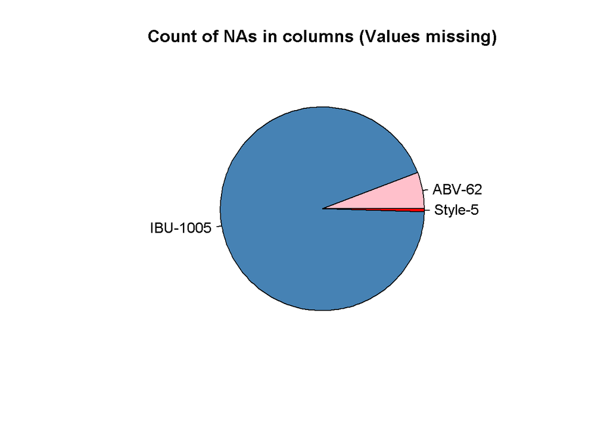

```r
pie(mytable, labels = lbls, main="Count of NAs in columns (Values missing)",col=c('pink','SteelBlue','red'))
```

```r
# Show the count for NA's in each column

kable(Data.NA, format = "markdown", padding = 2)
```

[output not shown]

### 4. Compute the median alcohol content and international bitterness unit for each state. Plot a bar chart to compare.

We build two new datasets, `Bitter` and `FireWater`, from our `BrewPub` dataset, omitting NA values. We then group the relevant values by state, and summarise by the median of the relevant value.

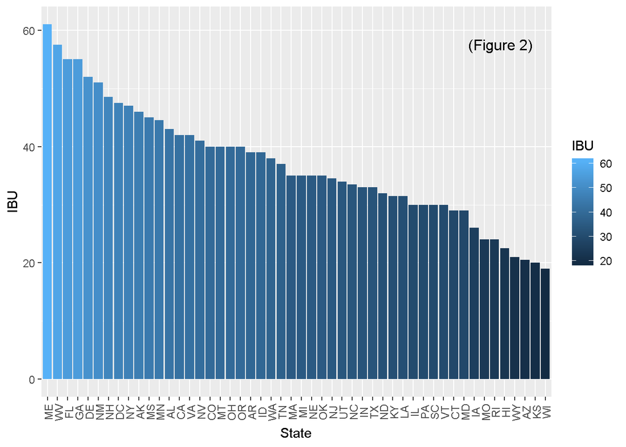

```r
ggplot2::ggplot(MergedData.Median, aes(reorder(State, -IBU), IBU, fill=IBU)) + geom_bar(stat = "identity") +
    theme(axis.text.x = element_text(angle=90, vjust=0.6), plot.title = element_text(hjust = 0.5)) +
    labs(x = 'State', y = 'IBU')
grid.text("(Figure 2)", 0.80, 0.90)
```

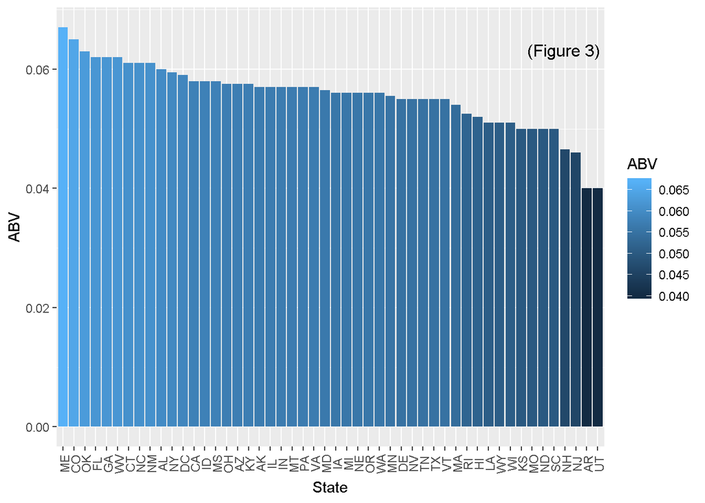

```r
ggplot2::ggplot(MergedData.Median, aes(reorder(State, -ABV), ABV, fill = ABV)) + geom_bar(stat = "identity") +
    theme(axis.text.x = element_text(angle=90, vjust=0.6), plot.title = element_text(hjust = 0.5)) +
    labs(x = 'State', y = 'ABV')
grid.text("(Figure 3)", 0.80, 0.90)
```

### 5. Which state has the maximum alcoholic (ABV) beer? Which state has the most bitter (IBU) beer?

We use `which.max` on our `BrewPub` dataset, seeking specifically the maximum value in the `ABV` and `IBU` columns.

From this, we identify Colorado as having the beer with the highest ABV, at `.128`; and we identify Oregon has having the beer with the highest IBU, at `138`.

### 6. Summary statistics for the ABV variable.

We do this by calling `summary` on the `ABV` column in our `BrewPub` dataset.

```r
kable(Data.Compare, format = "markdown", padding = 2)
```

| Maximum Alcoholic Beer | Max ABV | Most Bitter State | Most IBU |
| --- | --- | --- | --- |
| CO | 0.128 | OR | 138 |

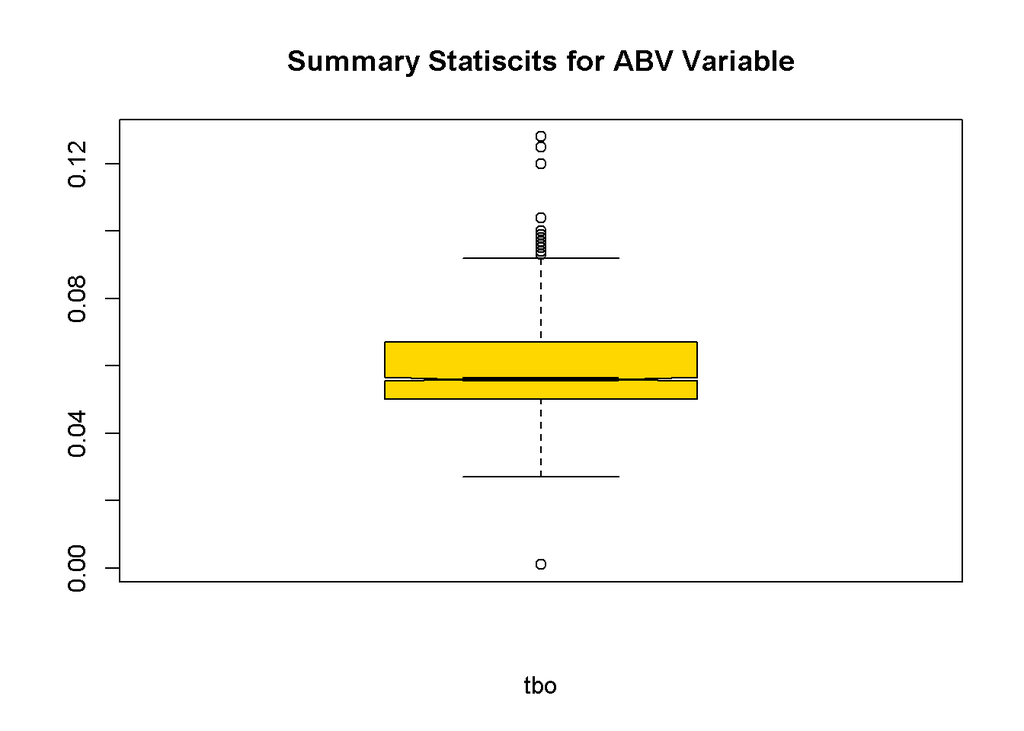

```r
# 6.    Summary statistics for the ABV variable. ????
Data.Summary <- summary(MergedData$ABV)
boxplot(MergedData$ABV, notch=TRUE,
  col=(c("gold","darkgreen")),
  main="Summary Statiscits for ABV Variable", xlab="tbo")
```

```r
Data.Summary
```

```
##    Min. 1st Qu.  Median    Mean 3rd Qu.    Max.    NA's
## 0.00100 0.05000 0.05600 0.05977 0.06700 0.12800      62
```

### 7. Is there an apparent relationship between the bitterness of the beer and its alcoholic content? Draw a scatter plot.

We utilize `ggplot` to plot a scatter plot of the data, using `IBU` and `ABV` as our variables.

Examination of this scatter plot and the regression line suggests that there is a positive, linear relationship between `IBU` and `ABV`.

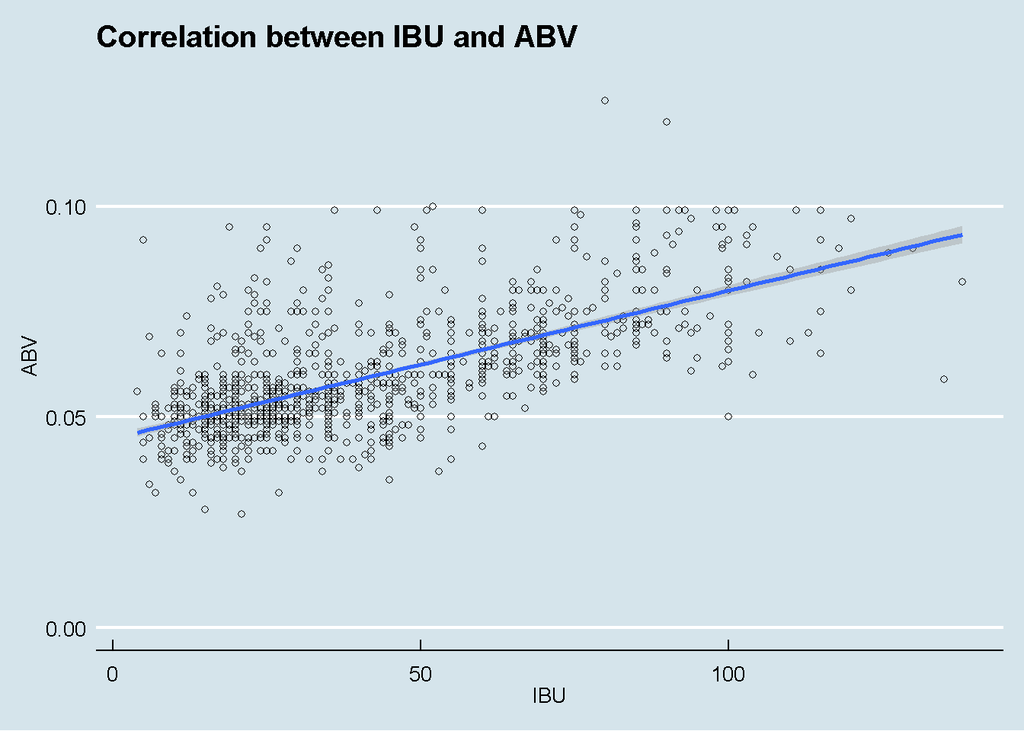

```r
# 7. Draw a scatter plot to compare relationship between beer
# bitterness and alcohol content
ggplot(MergedData, aes(x=MergedData$IBU, y= MergedData$ABV)) +
  geom_point(shape=1) +
   geom_smooth(method=lm) + # add linear regression line
  theme_economist() +
  scale_color_economist()+
  theme(axis.text.x=element_text(size=rel(1.0)))+
ggtitle("Correlation between IBU and ABV ") +
  labs(x="IBU",y="ABV")
```

## Review and Conclusion

In this analysis, we examined data gleaned from two datasets regarding beers and breweries throughout the US. We examined the structure of this data, cleaned them, and combined them. We then performed various analyses, such as calculating median values for IBU and ABV by state, and determining which states had the beers with the highest ABV and IBU values. We finished by looking for a potential relationship between IBU and ABV, and found that there is evidence to suggest that a positive correlation exists between the two.